# Bat survey in Plumas National Forest through the use of acoustic bat detectors

### author: Derek Corcoran

#### Last update: 2015-06-01

# Introduction

To study bat occupancy in the Plumas National Forest by surveying acustically different areas of the forest, the three objective species for this survey are the Pallid Bat, the Townsend’s Long-eared Bat, and the California Bat. Nevertheless, there is at least 14 species that form the bat ensemble in the National Forest, the list of species is the following

- *Tadarida brasiliensis* – free-tailed Bat
- *Antrozous pallidus* - **Pallid Bat**
- *Eptesicus fuscus* - Big Brown Bat
- *Euderma maculatum* - Spotted Bat
- *Lasionycteris noctivagans* - Silvered-haired Bat
- *Lasiurus blossevillii* - Western Red Bat
- *Lasiurus cinereus* - Hoary Bat
- *Corynorhinus townsendii* - **Townsend’s Long-eared Bat**
- *Myotis californicus* - **California Bat**
- *Myotis evotis* - Long-eared Bat
- *Myotis lucifugus* - Little Brown Bat
- *Myotis thysanodes* - Fringed Bat
- *Myotis volans* - Hairy-winged bat
- *Myotis yumanensis* - Yuma myotis

## Objective of the study

To determine the factors that influence bat occupancy in heterogeneous environments of Plumas National Forest, including areas corresponding to the Moonlight Fire and the Storrie Fire. Comparing and complementing biotic and abiotic variables.

# Specific research questions and the factors that might influence them

## 1. Which factors affect bat occupancy in burned forest?

### Does bat occupancy differ with the duration of time since the fire?

- Explanatory variable = burn age at sampling sites (mean number of years between fires for a given point and the time till the last fire for a given point).

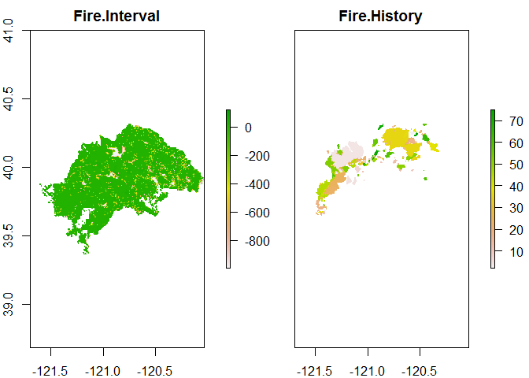

### Does bat occupancy differ with burn intensity

- Explanatory variable = burn intensity (in the following figure we see the layers that will allow us to work with burn intensity, this layers are burn intensity of the soil, burn intensity of the canopy, and Burn intensity of the basal area)

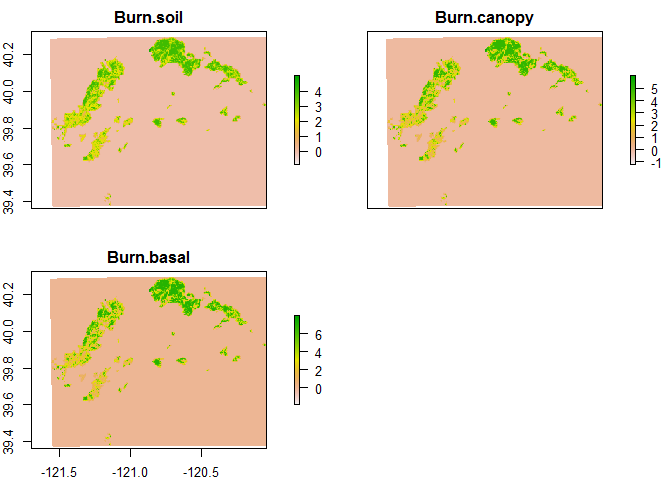

### Does bat occupancy differ with forest type

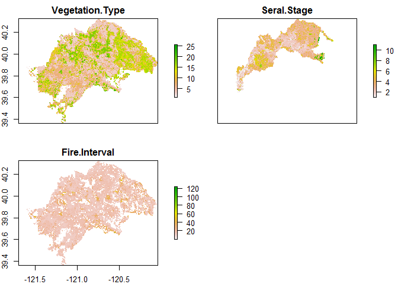

### Does bat occupancy differ with roost site availability?

- Explanatory variable = Associated forest metrics (Lidar???, distance to water)

**Concidering that we will work using lidar images, the layers to use will be acquired later, since most of this variables are only presented for del black polygon in the next figure.**

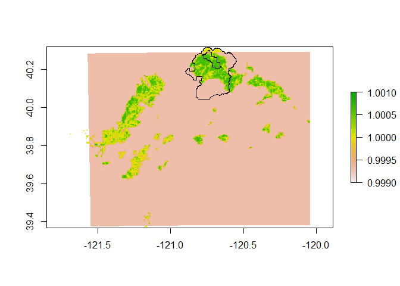

## Which factors affect bat occupancy in unburned forest?

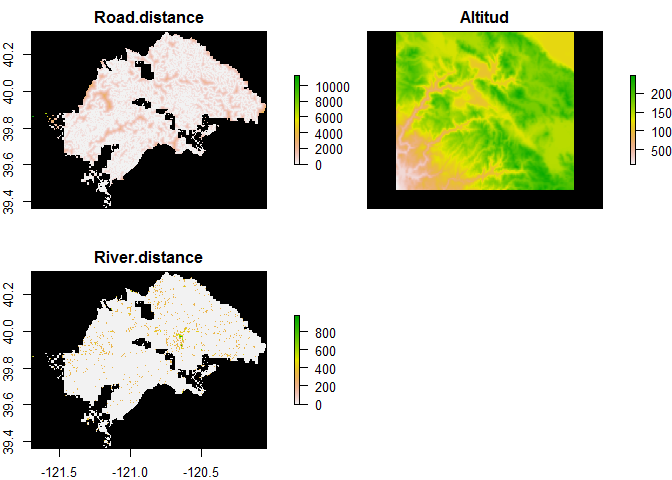

## Is occupancy affected by presence of heterospecifics?

### is bat occupancy affected by presence of other bats? (competition)

- Explanatory variable, occupancy of other bats (based on this study)

### is bat occupancy affected by the presence of preys?

- Explanatory variable, athropod emergence (Loren’s Study)

# Sampling desing and sampling unit

## Check for correlation between rasters

```
           slope
```

Min. 0.000000 1st Qu. 2.873498 Median 5.359555 3rd Qu. 8.648955 Max. 28.828351 NA’s 35684.000000

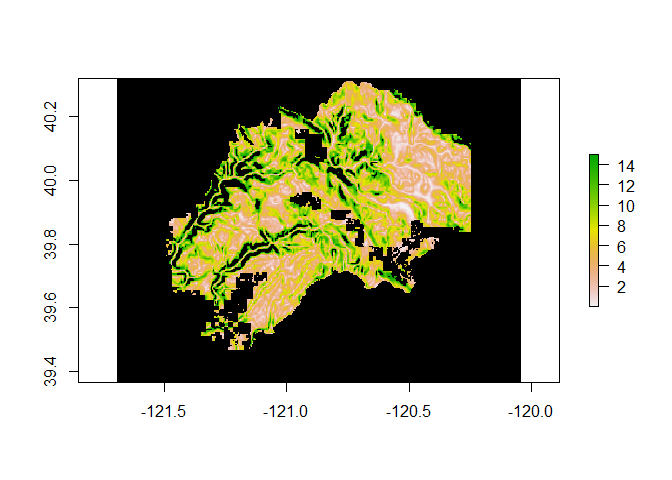

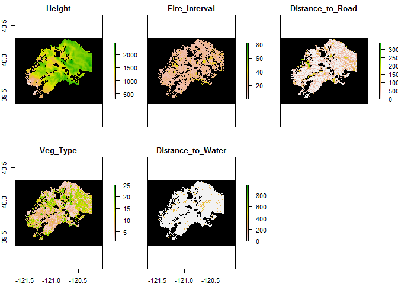

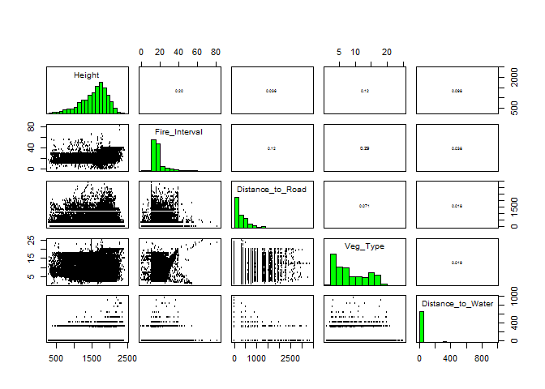

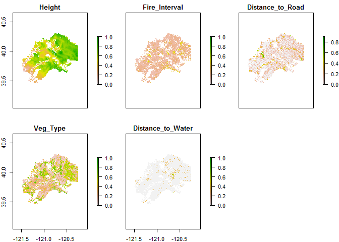

# Clasification

Now we will use kmeans to sort the area into 5 types of habitat using the abovementioned rasterstack, and it will be ploted with different colors for every type of environment.

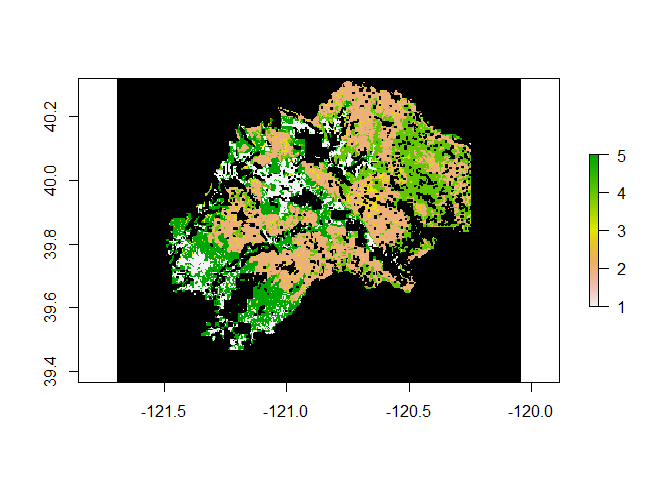

More info on how to do this clasification in *https://geoscripting-wur.github.io/AdvancedRasterAnalysis/*

# separate layers acording to places with or without fire

Now we will separate the whole area in two subtypes burned areas and non-buned areas, based on the burn severity layers

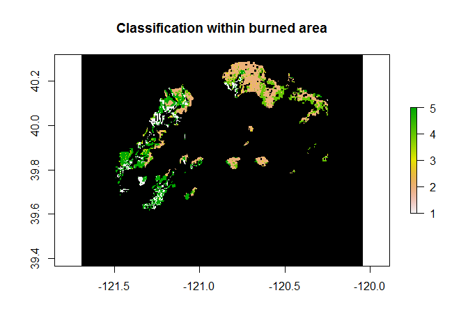

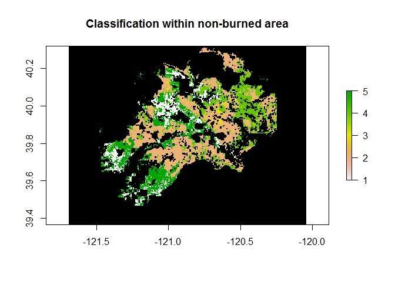

# Extract Random points from each habitat type with equal number in fire and non fire

During the first year of sampling 120 samples will be colected, 60 in burned areas, and 60 in non-burned areas, within each, 12 random points will be sampled in each habtitat type defined by the K-means classification.

- 60 random points in not Fire, 12 random points per each environment type
- 60 random points in Fire, 12 random points per each environment type
- We plot the chosen random points over the topographic map, each color is an environment type, full circles are places where there was no fire, and full triangles, where there was a fire

[output not shown]

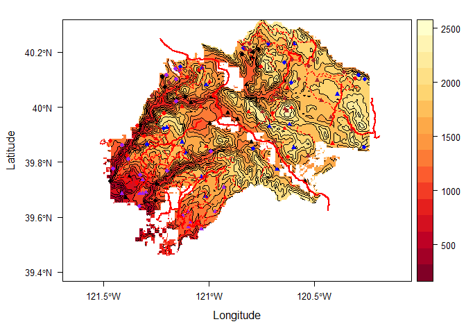

### Values

Mean value for every variable for each ID which combines prior classification (1 to 5) and fire or no fire (f or nf)

[output not shown]

# Simulated sampling Dynamic modeling

```r
library("unmarked", lib.loc="~/R/win-library/3.2")
```

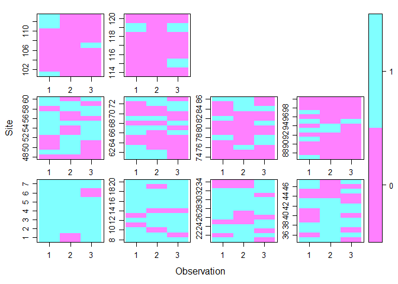

```
##        nPars    AIC delta   AICwt cumltvWt
## Model1     2 481.49  0.00 0.99931     1.00
## Model3     7 496.92 15.43 0.00045     1.00
## Model2     8 498.12 16.62 0.00025     1.00
```

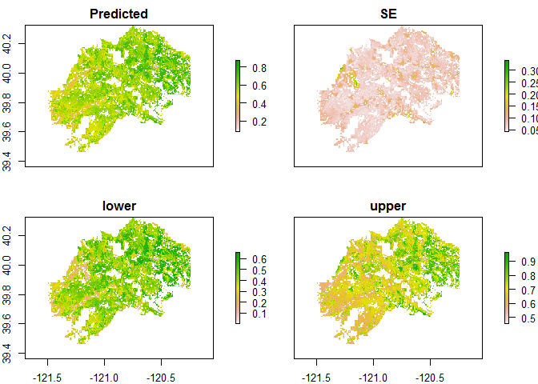

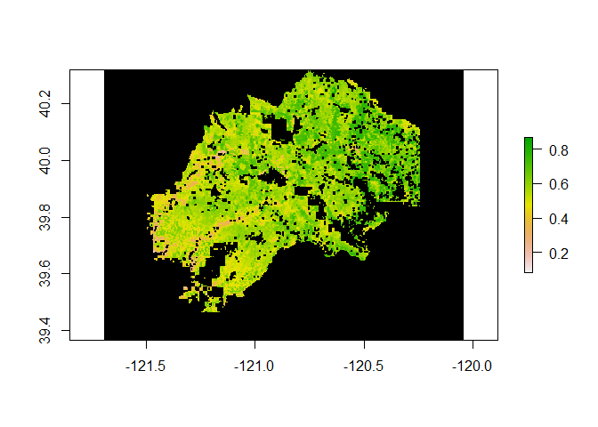

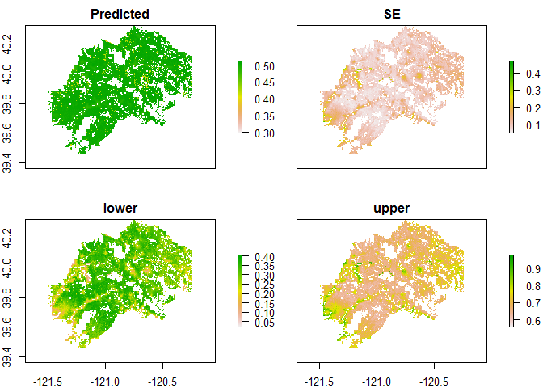

```
##    Predicted
##  Min.   :0.08
##  1st Qu.:0.52
##  Median :0.58
##  Mean   :0.58
##  3rd Qu.:0.64
##  Max.   :0.87
##  NA's   :74441
```

```
## [1] 19720.2
```

```
## [1] 14501.36
```

```
## [1] 24518.73
```

# APENDIX

## Apendix 1

Values recorded for each selected sampling point toghether with it’s ID

| Long | Lat | Height | Fire Interval | Distance to Road | Vegetation Type | Distance to Water | ID |
| --- | --- | --- | --- | --- | --- | --- | --- |
| 120.91 | 39.98 | 1145.27 | 15.81 | 424.21 | 12.41 | 0.00 | 1nf |
| 121.09 | 40.02 | 983.53 | 11.68 | 0.00 | 10.22 | 0.00 | 1nf |
| 120.87 | 39.96 | 1237.23 | 25.68 | 0.00 | 12.37 | 0.00 | 1nf |
| 121.00 | 39.94 | 1279.09 | 21.48 | 0.00 | 11.73 | 0.00 | 1nf |
| 120.80 | 39.87 | 1424.25 | 15.16 | 424.21 | 15.47 | 0.00 | 1nf |
| 121.38 | 39.75 | 797.21 | 21.40 | 0.00 | 18.00 | 0.00 | 1nf |
| 120.82 | 40.08 | 1241.51 | 19.82 | 0.00 | 14.47 | 0.00 | 1nf |
| 120.98 | 40.04 | 1010.16 | 26.50 | 0.00 | 18.00 | 0.00 | 1nf |
| 121.40 | 39.67 | 757.34 | 17.29 | 0.00 | 10.82 | 0.00 | 1nf |
| 120.64 | 40.10 | 1411.36 | 16.00 | 0.00 | 18.00 | 0.00 | 1nf |
| 120.55 | 39.73 | 1428.79 | 12.89 | 0.00 | 16.76 | 0.00 | 1nf |
| 120.99 | 40.04 | 1005.39 | 23.42 | 0.00 | 18.00 | 0.00 | 1nf |
| 120.80 | 40.18 | 1280.15 | 16.42 | 0.00 | 17.61 | 0.00 | 1f |
| 121.25 | 39.72 | 731.23 | 16.00 | 0.00 | 12.28 | 0.00 | 1f |
| 121.25 | 39.66 | 946.98 | 14.42 | 848.42 | 13.27 | 0.00 | 1f |
| 121.21 | 40.07 | 1098.96 | 19.60 | 1428.69 | 14.79 | 0.00 | 1f |
| 121.22 | 40.11 | 1302.51 | 16.00 | 324.43 | 18.00 | 0.00 | 1f |
| 120.84 | 40.19 | 1410.15 | 17.48 | 908.19 | 10.71 | 0.00 | 1f |
| 121.22 | 40.11 | 1243.52 | 15.68 | 0.00 | 17.04 | 0.00 | 1f |
| 121.42 | 39.83 | 584.98 | 16.00 | 0.00 | 10.43 | 0.00 | 1f |
| 120.79 | 40.20 | 1393.51 | 16.00 | 533.80 | 18.00 | 0.00 | 1f |
| 120.76 | 40.21 | 1335.86 | 14.71 | 0.00 | 14.14 | 0.00 | 1f |
| 121.11 | 40.04 | 1039.99 | 20.12 | 534.28 | 18.00 | 0.00 | 1f |
| 121.47 | 39.73 | 434.85 | 11.25 | 0.00 | 9.42 | 0.00 | 1f |
| 120.71 | 39.93 | 2069.65 | 7.16 | 0.00 | 6.93 | 0.00 | 2nf |
| 120.60 | 39.85 | 2004.34 | 16.00 | 0.00 | 4.29 | 0.00 | 2nf |
| 121.13 | 39.87 | 1790.30 | 16.00 | 325.57 | 7.00 | 0.00 | 2nf |
| 121.02 | 39.67 | 1580.89 | 16.00 | 0.00 | 6.93 | 0.00 | 2nf |
| 120.39 | 40.05 | 1911.05 | 16.00 | 324.74 | 3.00 | 0.00 | 2nf |
| 121.04 | 39.75 | 1771.12 | 16.00 | 0.00 | 6.54 | 0.00 | 2nf |

[output cut: 90 more lines]

Simulated Sampling values

|  | night1 | night2 | night3 |
| --- | --- | --- | --- |
| s1.1nf | 1 | 0 | 1 |
| s2.1nf | 1 | 1 | 1 |
| s3.1nf | 1 | 1 | 1 |
| s4.1nf | 1 | 1 | 1 |
| s5.1nf | 1 | 1 | 1 |
| s6.1nf | 1 | 1 | 0 |
| s7.1nf | 1 | 1 | 1 |
| s8.1nf | 1 | 1 | 1 |
| s9.1nf | 1 | 1 | 0 |
| s10.1nf | 1 | 0 | 1 |
| s11.1nf | 0 | 1 | 1 |
| s12.1nf | 1 | 1 | 1 |
| s1.1f | 0 | 1 | 1 |
| s2.1f | 1 | 0 | 0 |
| s3.1f | 1 | 1 | 1 |
| s4.1f | 1 | 1 | 1 |
| s5.1f | 1 | 1 | 1 |
| s6.1f | 1 | 1 | 1 |
| s7.1f | 1 | 0 | 1 |
| s8.1f | 1 | 1 | 1 |
| s9.1f | 1 | 1 | 0 |
| s10.1f | 0 | 1 | 1 |
| s11.1f | 1 | 1 | 0 |
| s12.1f | 1 | 1 | 1 |
| s1.2nf | 0 | 0 | 1 |
| s2.2nf | 1 | 0 | 0 |
| s3.2nf | 1 | 0 | 1 |
| s4.2nf | 1 | 1 | 1 |
| s5.2nf | 1 | 1 | 1 |
| s6.2nf | 1 | 1 | 1 |

[output cut: 90 more lines]